# Logistic Regression - Extended Examples

Brian Powers

2023-04-13

## The Pima dataset - predicting diabetes

```r
library(MASS)
head(Pima.te)
```

```
##   npreg glu bp skin  bmi   ped age type
## 1     6 148 72   35 33.6 0.627  50  Yes
## 2     1  85 66   29 26.6 0.351  31   No
## 3     1  89 66   23 28.1 0.167  21   No
## 4     3  78 50   32 31.0 0.248  26  Yes
## 5     2 197 70   45 30.5 0.158  53  Yes
## 6     5 166 72   19 25.8 0.587  51  Yes
```

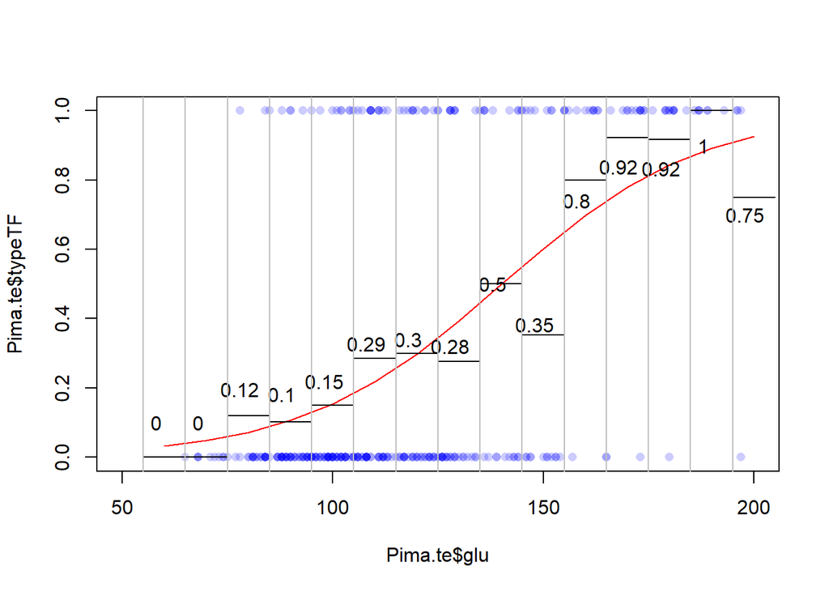

```r
Pima.te$glu_bin <- (round(Pima.te$glu/10))*10
Pima.te$typeTF <- as.numeric(Pima.te$type=="Yes")
Pima.glm <- glm(typeTF ~ glu, data=Pima.te, family="binomial")

aggr.props <- aggregate(typeTF ~ glu_bin, data=Pima.te, FUN=mean)

xs <- seq(60,200,10)
zs <- predict(Pima.glm, newdata=data.frame(glu=xs))
ps <- exp(zs)/(1+exp(zs))

plot(x=Pima.te$glu, y=Pima.te$typeTF, pch=16, col=rgb(0,0,1,.2), xlim=c(50,200))
#points(aggr.props, ylim=c(0,1))
lines(x=xs,y=ps, col="red")
text(x=xs-2, y=as.vector(aggr.props$typeTF*.8+.5*.2), label=round(aggr.props$typeTF,2))
segments(x0=xs-5, aggr.props$typeTF, xs+5,aggr.props$typeTF)
abline(v=seq(55,195,10), col="gray")
```

Model summary

```r
summary(Pima.glm)
```

```
##
## Call:
## glm(formula = typeTF ~ glu, family = "binomial", data = Pima.te)
##
## Deviance Residuals:
##     Min       1Q   Median       3Q      Max
## -2.2343  -0.7270  -0.4985   0.6663   2.3268
##
## Coefficients:
##              Estimate Std. Error z value Pr(>|z|)
## (Intercept) -5.946808   0.659839  -9.013   <2e-16 ***
## glu          0.042421   0.005165   8.213   <2e-16 ***
## ---
## Signif. codes:  0 '***' 0.001 '**' 0.01 '*' 0.05 '.' 0.1 ' ' 1
##
## (Dispersion parameter for binomial family taken to be 1)
##
##     Null deviance: 420.30  on 331  degrees of freedom
## Residual deviance: 325.99  on 330  degrees of freedom
## AIC: 329.99
##
## Number of Fisher Scoring iterations: 4
```

## Odds Ratios

Odds Ratio = Odds(Event | Case A) / Odds(Event | Case B) We look at odds ratio when the cases differe by an increase of 1 unit in the predictor $x$. $\beta_1$ is the log of the odds ratio associated with a 1 unit increase in $x$.

The log(odds ratio)=0.042421

The odds ratio = exp(0.042421)

```r
exp(0.042421)
```

```
## [1] 1.043334
```

### Interpret the slope

```r
Pima.glm$coefficients[2]
```

```
##        glu
## 0.04242098
```

```r
exp(Pima.glm$coefficients[2])
```

```
##      glu
## 1.043334
```

Odd ratio for a 1 unit increase in blood glucose is 1.0433 so if we hold all other variables constant and increase blood glucose by 1 unit, we expect an increase in the Odds by 4.33%

### odds ratio vs risk ratio

Risk is Prob(Event | case A) / Pr(Event | Case B) which is not the same as odds ratio. Consider this example:

Predict probability for glu 200 vs 201

```r
predict(Pima.glm, type="response", newdata=data.frame(glu=c(200,201)))
```

```
##         1         2
## 0.9267217 0.9295508
```

```r
#The risk ratio is
0.9295508 / 0.9267217
```

```
## [1] 1.003053
```

```r
#The Odds ratio is
(0.9295508/(1-0.9295508)) / (0.9267217/(1-0.9267217))
```

```
## [1] 1.043333
```

Compare glu 100 to 101

```r
predict(Pima.glm, type="response", newdata=data.frame(glu=c(100,101)))
```

```
##         1         2
## 0.1538511 0.1594550
```

```r
#The risk ratio is
0.1594550 / 0.1538511
```

```
## [1] 1.036424
```

```r
#The Odds ratio is
(0.1594550/(1-0.1594550)) / (0.1538511 /(1-0.1538511 ))
```

```
## [1] 1.043334
```

The risk ratios are different but the odds ratio is a constant 1.04333

## Log Likelihood

log likelihood calculation Let’s compare the true Y values and the predicted Y values

```r
y <- Pima.te$typeTF

y.hat <- predict(Pima.glm, type="response")
pY <- y * y.hat + (1-y)*(1-y.hat)
head(data.frame(y,y.hat,pY),10)
```

```
##    y      y.hat         pY
## 1  1 0.58212363 0.58212363
## 2  0 0.08778183 0.91221817
## 3  0 0.10235379 0.89764621
## 4  1 0.06673426 0.06673426
## 5  1 0.91759616 0.91759616
## 6  1 0.74933615 0.74933615
## 7  1 0.28067169 0.28067169
## 8  0 0.17115736 0.82884264
## 9  0 0.35394014 0.64605986
## 10 1 0.28931541 0.28931541
```

The likelihood is the product of predicted probabilities (of the actual label) For actual 1s, we use y.hat For actual 0s we use 1-y.hat

```r
L <- prod(y * y.hat + (1-y)*(1-y.hat))
L
```

```
## [1] 1.629075e-71
```

Maximizing likelihood is equivalent to maximising the log of likelihood, and because logarithms turn products into sums, the log likelihood is easier to work with mathematically. Because likelihood < 1, log likelihood is going to be negative.

```r
log(L)
```

```
## [1] -162.9955
```

```r
l <- sum(log(y * y.hat + (1-y)*(1-y.hat)))
l
```

```
## [1] -162.9955
```

The closer to zero the log likelihood is, the better; The closer to -infinity, the “worse”. The residual deviance is defined as -2 times the log likelihood. It turns a big negative log likelihood into a large positive number (easier to interpret)

```r
#residual deviance
-2*l
```

```
## [1] 325.9911
```

For each observation, we can translate $P(Y=y | model)$ into a log-likelihood by just taking the log of that decimal. Furthermore, we could multiply each of these by -2 to see which data points contribute more (or less) to the total “residual deviance”

```r
ll <- log(pY)
head(data.frame(y,y.hat,pY, ll, -2*ll),10)
```

```
##    y      y.hat         pY         ll  X.2...ll
## 1  1 0.58212363 0.58212363 -0.5410724 1.0821449
## 2  0 0.08778183 0.91221817 -0.0918761 0.1837522
## 3  0 0.10235379 0.89764621 -0.1079793 0.2159585
## 4  1 0.06673426 0.06673426 -2.7070368 5.4140735
## 5  1 0.91759616 0.91759616 -0.0859979 0.1719958
## 6  1 0.74933615 0.74933615 -0.2885676 0.5771352
## 7  1 0.28067169 0.28067169 -1.2705696 2.5411393
## 8  0 0.17115736 0.82884264 -0.1877250 0.3754499
## 9  0 0.35394014 0.64605986 -0.4368631 0.8737262
## 10 1 0.28931541 0.28931541 -1.2402378 2.4804756
```

## Prediction

Suppose someone has glucose level 150; what is the estimated probability of diabetes?
$$\hat{logodds}(Y+i=1) =
\hat{\beta_0}+\hat{\beta_1}X_i$$

```r
#Predict log odds
predict(Pima.glm, newdata=data.frame(glu=150))
```

```
##         1
## 0.4163392
```

```r
#Predicts probability
predict(Pima.glm, newdata=data.frame(glu=150), type="response")
```

```
##         1
## 0.6026069
```

```r
#calculation
log.odds.150 <- sum(Pima.glm$coefficients * c(1, 150))

#Estimated probability = e^log-odds / (1+e^log-odds)
#or
#                      = 1/ (1 + e^ -logodds)
exp(log.odds.150) / (1+ exp(log.odds.150))
```

```
## [1] 0.6026069
```

```r
#or
1 / (1+ exp(-log.odds.150))
```

```
## [1] 0.6026069
```

## The null model

The null model would be what we compare our “better” model to - it is a logistic model that does not have any predictors. Just like the null model for linear regression predicts $\hat{y}=\bar{y}$ the null model predicts $\hat{y}=$ the proportion of 1s in the data set.

```r
pima.glm.null <- glm(typeTF ~ 1, data=Pima.te, family="binomial")
summary(pima.glm.null)
```

```
##
## Call:
## glm(formula = typeTF ~ 1, family = "binomial", data = Pima.te)
##
## Deviance Residuals:
##     Min       1Q   Median       3Q      Max
## -0.8921  -0.8921  -0.8921   1.4925   1.4925
##
## Coefficients:
##             Estimate Std. Error z value Pr(>|z|)
## (Intercept)  -0.7158     0.1169  -6.125 9.07e-10 ***
## ---
## Signif. codes:  0 '***' 0.001 '**' 0.01 '*' 0.05 '.' 0.1 ' ' 1
##
## (Dispersion parameter for binomial family taken to be 1)
##
##     Null deviance: 420.3  on 331  degrees of freedom
## Residual deviance: 420.3  on 331  degrees of freedom
## AIC: 422.3
##
## Number of Fisher Scoring iterations: 4
```

```r
log.odds <- pima.glm.null$coefficients[1]
exp(log.odds) / (1+ exp(log.odds))
```

```
## (Intercept)
##   0.3283133
```

```r
mean(Pima.te$typeTF)
```

```
## [1] 0.3283133
```

Let’s just double check that. We can calculate the coefficient manually

```r
#What is the proportion of 1s in the data?
(prop1 <- mean(Pima.te$typeTF))
```

```
## [1] 0.3283133
```

```r
#convert this to a log-odds
log(prop1/(1-prop1))
```

```
## [1] -0.7158239
```

This is the same as the constant in the null model.

```r
#null deviance calculation

#log likelihood = sum [y * y.hat + (1-y)*(1-yhat)]

#deviance = -2*log likelihood

n <- nrow(Pima.te)
m <- sum(Pima.te$typeTF)
-2*(m*log(m/n) + (n-m)*log((n-m)/n))
```

```
## [1] 420.2972
```

## Results of logistic regression: confusion matrix

See https://en.wikipedia.org/wiki/Confusion_matrix

```r
pima_logit <- glm(typeTF ~ glu, data=Pima.te, family="binomial")

confusion.table <- table(Pima.te$typeTF, factor(predict(pima_logit, type="response") >= .5, levels=c(FALSE, TRUE)))

colnames(confusion.table) <- c("Predict 0","Predict 1")
rownames(confusion.table) <- c("No diabetes","Yes diabetes")

#confusion.table
TP <- confusion.table[2,2]
TN <- confusion.table[1,1]
FP <- confusion.table[1,2]
FN <- confusion.table[2,1]

t(addmargins(confusion.table))
```

```
##
##             No diabetes Yes diabetes Sum
##   Predict 0         200           53 253
##   Predict 1          23           56  79
##   Sum               223          109 332
```

Statistics for a predictor:

Accuracy of a classifier - the total # correct predictions / total predictions

```r
(accuracy <- (TP+TN)/(TP+TN+FP+FN))
```

```
## [1] 0.7710843
```

Sensitivity (aka recall, hit rate, true positive rate, aka POWER) - what proportion of actual positive cases are classified as positive

```r
(sensitivity <- TP / (TP+FN))
```

```
## [1] 0.5137615
```

Specificity (selectivity, true negative rate, $1-\alpha$) - what proportion of actual negative cases are classified as negative

```r
(specificity <- TN / (TN+FP))
```

```
## [1] 0.896861
```

Precision (positive predictive value) - what proportion of positive predictions are correct

```r
(ppv <- TP/(TP+FP))
```

```
## [1] 0.7088608
```

Negative Predictive Value (NPV) - what proportion of negative predictions are correct

```r
(npv <- TN/(TN+FN))
```

```
## [1] 0.7905138
```

What was the Type 1 error rate? The False positive rate

```r
FP / (FP + TN)
```

```
## [1] 0.103139
```

Let’s just change the theshold from $p=.5$ to some other number to see what happens to this matrix.

```r
confusion.table <- table(Pima.te$typeTF, factor(predict(pima_logit, type="response") >= .6, levels=c(FALSE, TRUE)))
colnames(confusion.table) <- c("Predict 0","Predict 1")
rownames(confusion.table) <- c("No diabetes","Yes diabetes")
#confusion.table
t(addmargins(confusion.table))
```

```
##
##             No diabetes Yes diabetes Sum
##   Predict 0         210           61 271
##   Predict 1          13           48  61
##   Sum               223          109 332
```

```r
#column proportions
prop.table(t(confusion.table), 2)
```

```
##
##             No diabetes Yes diabetes
##   Predict 0  0.94170404   0.55963303
##   Predict 1  0.05829596   0.44036697
```

If I look at column proportions, the first column (bottom row) is the alpha, type 1 error rate i.e. FPR. Column 2, in row 2 gives power.

The accuracy is (210 + 48 ) / 332

```r
(210 + 48  ) / 332
```

```
## [1] 0.7771084
```

By adjusting the positive prediction threshold we can improve/worsen statistics such as accuracy, specificity, sensitivity, etc.

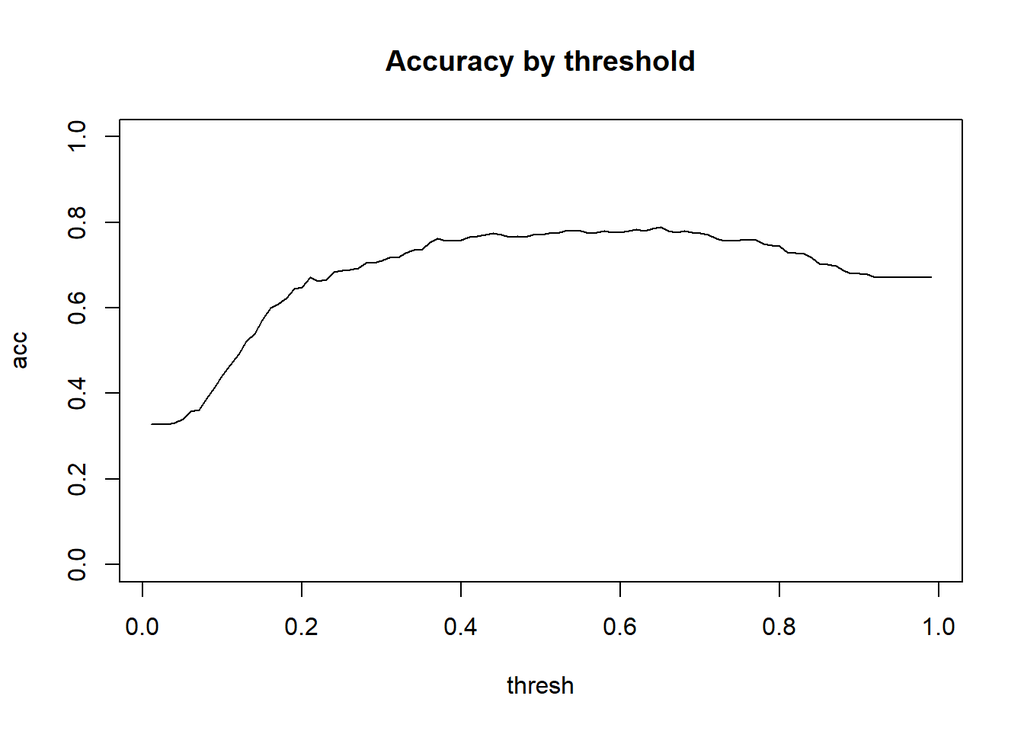

```r
pima_logit <- glm(typeTF ~ glu, data=Pima.te, family="binomial")
acc <- 0
thresh <- seq(0.01, 0.99, .01)
for(i in 1:length(thresh)){
  confusion.table <- table(Pima.te$typeTF, factor(predict(pima_logit, type="response")>= thresh[i], levels=c(FALSE, TRUE)))
  colnames(confusion.table) <- c("Predict 0","Predict 1")
  rownames(confusion.table) <- c("No diabetes","Yes diabetes")
  #confusion.table
  TP <- confusion.table[2,2]
  TN <- confusion.table[1,1]
  FP <- confusion.table[1,2]
  FN <- confusion.table[2,1]
  acc[i] = (TP+TN)/(TP+FP+TN+FN)
}
plot(thresh, acc, type="l", main="Accuracy by threshold", ylim=c(0,1))
```

In particular, we can look at the relationship between True positive rate and False Positive Rate (what proportion of actual negatives are incorrectly predicted to be positive) (FP / (FP+TN))

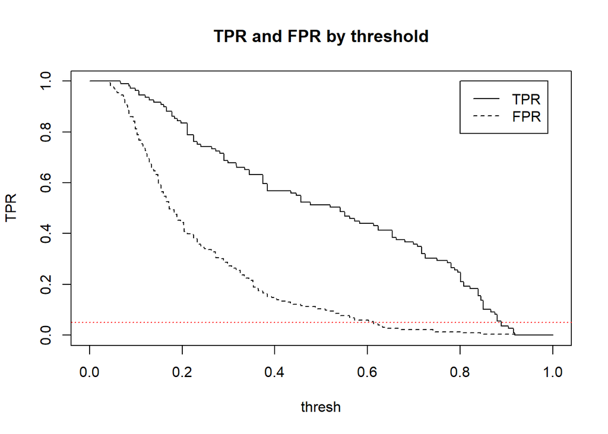

```r
TPR <- 0; FPR <- 0;
thresh <- seq(0, 1, .001)
for(i in 1:length(thresh)){
  confusion.table <- table(Pima.te$typeTF, factor(predict(pima_logit, type="response")>= thresh[i], levels=c(FALSE, TRUE)))
  colnames(confusion.table) <- c("Predict 0","Predict 1")
  rownames(confusion.table) <- c("No diabetes","Yes diabetes")
  #confusion.table
  TP <- confusion.table[2,2]
  TN <- confusion.table[1,1]
  FP <- confusion.table[1,2]
  FN <- confusion.table[2,1]

  TPR[i] <- TP/(TP+FN) #power
  FPR[i] <- FP/(FP+TN) #alpha / significance / type 1 error
}
plot(thresh, TPR, type="n", main="TPR and FPR by threshold", xlim=c(0,1), ylim=c(0,1))
lines(thresh, TPR, lty=1)
lines(thresh, FPR, lty=2)
abline(h=0.05, col="red", lty=3)
legend(x=.8, y=1, legend = c("TPR", "FPR"), lty=c(1,2))
```

To put things into the language of hypothesis testing we could ask this: What threshold would we use to achieve a 5% significance level (false positive rate) and what would the power of the classifier be?

```r
optimalThresh <- min(which(FPR<=0.05))
thresh[optimalThresh]
```

```
## [1] 0.613
```

```r
as.numeric(FPR[optimalThresh])
```

```
## [1] 0.04484305
```

```r
as.numeric(TPR[optimalThresh])
```

```
## [1] 0.4311927
```

```r
#data.frame(TPR, FPR)
```

A scatterplot of these rates is called the ROC curve. We start at (0,0) and go to (1,1)

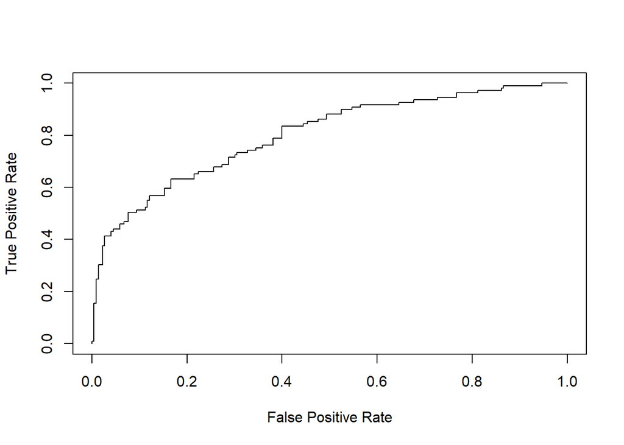

```r
plot(c(1,FPR,0),c(1, TPR,0), type="s", xlab="False Positive Rate", ylab="True Positive Rate")
```

The PRROC package produces pretty ROC curves.

```r
#install.packages("PRROC")
library(PRROC)
```

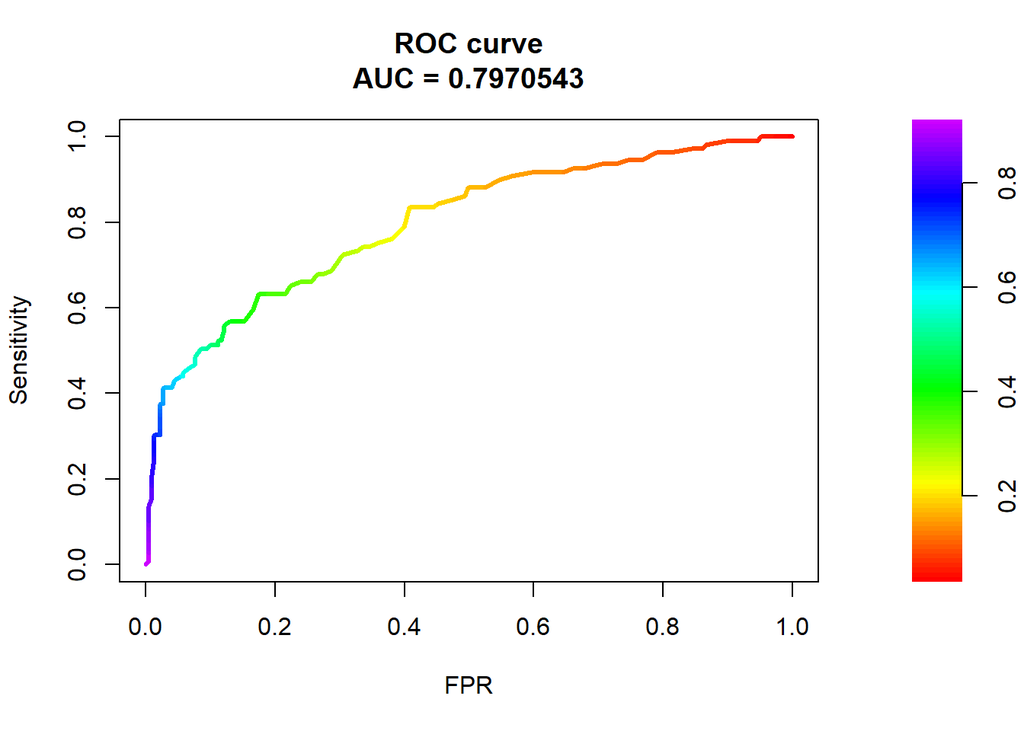

```r
PRROC_obj <- roc.curve(scores.class0 = predict(pima_logit, type="response"),
                       weights.class0=Pima.te$typeTF,
                       curve=TRUE)
plot(PRROC_obj)
```

The area under the curve (AUC) is a common metric measuring how good your classifier is. An AUC = 0.5 (where the ROC curve is a diagonal line) is a “dumb” predictor. AUC closer to 1 represents a discerning “good” predictor.

## Comparing using AIC and BIC

As we’ll see next week, the AIC is a useful statistic to compare logistic models.
$$AIC = \text{residual
deviance} + 2k\text{ (k is the number of coefficients fit)}$$
$$BIC = \text{residual deviance} +
ln(n)*k$$
When sample size is large then BIC will give a larger penalty per predictor. $ln(8) > 2$ so when $n \geq 8$ BIC gives a heftier penalty per coefficient in the model than AIC does and thus will favor simpler models.

When using either of these comparative statistics, the *lower* the value the better.

```r
pima.logit1 <- glm(typeTF ~ 1 + glu,data=Pima.te, family="binomial")
pima.logit2 <- glm(typeTF ~ 1 + glu + bmi, data=Pima.te, family="binomial")
summary(pima.logit1)
```

```
##
## Call:
## glm(formula = typeTF ~ 1 + glu, family = "binomial", data = Pima.te)
##
## Deviance Residuals:
##     Min       1Q   Median       3Q      Max
## -2.2343  -0.7270  -0.4985   0.6663   2.3268
##
## Coefficients:
##              Estimate Std. Error z value Pr(>|z|)
## (Intercept) -5.946808   0.659839  -9.013   <2e-16 ***
## glu          0.042421   0.005165   8.213   <2e-16 ***
## ---
## Signif. codes:  0 '***' 0.001 '**' 0.01 '*' 0.05 '.' 0.1 ' ' 1
##
## (Dispersion parameter for binomial family taken to be 1)
##
##     Null deviance: 420.30  on 331  degrees of freedom
## Residual deviance: 325.99  on 330  degrees of freedom
## AIC: 329.99
##
## Number of Fisher Scoring iterations: 4
```

```r
summary(pima.logit2)
```

```
##
## Call:
## glm(formula = typeTF ~ 1 + glu + bmi, family = "binomial", data = Pima.te)
##
## Deviance Residuals:
##     Min       1Q   Median       3Q      Max
## -2.2240  -0.7216  -0.4421   0.6158   2.3544
##
## Coefficients:
##              Estimate Std. Error z value Pr(>|z|)
## (Intercept) -8.025302   0.942896  -8.511  < 2e-16 ***
## glu          0.039311   0.005257   7.478 7.57e-14 ***
## bmi          0.072645   0.020621   3.523 0.000427 ***
## ---
## Signif. codes:  0 '***' 0.001 '**' 0.01 '*' 0.05 '.' 0.1 ' ' 1
##
## (Dispersion parameter for binomial family taken to be 1)
##
##     Null deviance: 420.30  on 331  degrees of freedom
## Residual deviance: 312.49  on 329  degrees of freedom
## AIC: 318.49
##
## Number of Fisher Scoring iterations: 4
```

## Example 2: A Logistic model with a categorical predictor

```r
#Let's use age as a predictor
#Only for age > 50
Pima.te$age50 <- as.numeric(Pima.te$age > 50)

diabetes.aggr <- aggregate(typeTF ~ age50, data=Pima.te, FUN=mean)
diabetes.aggr
```

```
##   age50    typeTF
## 1     0 0.3129032
## 2     1 0.5454545
```

Among those 50 or younger, proportion with diabetes is .3129032 among those 51+ it is .545454

```r
#Log-odds for the two groups
odds <- diabetes.aggr$typeTF / (1-diabetes.aggr$typeTF)
odds
```

```
## [1] 0.4553991 1.2000000
```

```r
logodds <- log(odds)
logodds
```

```
## [1] -0.7865812  0.1823216
```

```r
diff(logodds)
```

```
## [1] 0.9689027
```

Notice the log-odds are -.7865 and .1823 respectively. If we were to build a model we would say that
$$\hat{LO} =
-.7865812 + .9689 \times age_{>50}$$

```r
Pima50 <- glm(typeTF ~ age50, data=Pima.te, family="binomial")
summary(Pima50)
```

```
##
## Call:
## glm(formula = typeTF ~ age50, family = "binomial", data = Pima.te)
##
## Deviance Residuals:
##     Min       1Q   Median       3Q      Max
## -1.2557  -0.8663  -0.8663   1.5244   1.5244
##
## Coefficients:
##             Estimate Std. Error z value Pr(>|z|)
## (Intercept)  -0.7866     0.1225  -6.422 1.35e-10 ***
## age50         0.9689     0.4454   2.176   0.0296 *
## ---
## Signif. codes:  0 '***' 0.001 '**' 0.01 '*' 0.05 '.' 0.1 ' ' 1
##
## (Dispersion parameter for binomial family taken to be 1)
##
##     Null deviance: 420.30  on 331  degrees of freedom
## Residual deviance: 415.59  on 330  degrees of freedom
## AIC: 419.59
##
## Number of Fisher Scoring iterations: 4
```

## Example 3: Iris dataset

Another classic example is the `iris` dataset. This famous dataset gives measurements in centimeters of the sepal and petal width and length for 3 species of iris: setosa, versicolor and virginica. The dataset has 150 rows, with 50 samples of each.

Because the logistic model handles binary response variables, what we will do is create a logistic model to predict whether an iris is virginica Let’s build a full model with all 4 predictors.

```r
virginica.model <- glm(Species=="virginica" ~ 1 + Sepal.Length + Sepal.Width+Petal.Length+Petal.Width, data=iris, family="binomial")
summary(virginica.model)
```

```
##
## Call:
## glm(formula = Species == "virginica" ~ 1 + Sepal.Length + Sepal.Width +
##     Petal.Length + Petal.Width, family = "binomial", data = iris)
##
## Deviance Residuals:
##      Min        1Q    Median        3Q       Max
## -2.01105  -0.00065   0.00000   0.00048   1.78065
##
## Coefficients:
##              Estimate Std. Error z value Pr(>|z|)
## (Intercept)   -42.638     25.708  -1.659   0.0972 .
## Sepal.Length   -2.465      2.394  -1.030   0.3032
## Sepal.Width    -6.681      4.480  -1.491   0.1359
## Petal.Length    9.429      4.737   1.990   0.0465 *
## Petal.Width    18.286      9.743   1.877   0.0605 .
## ---
## Signif. codes:  0 '***' 0.001 '**' 0.01 '*' 0.05 '.' 0.1 ' ' 1
##
## (Dispersion parameter for binomial family taken to be 1)
##
##     Null deviance: 190.954  on 149  degrees of freedom
## Residual deviance:  11.899  on 145  degrees of freedom
## AIC: 21.899
##
## Number of Fisher Scoring iterations: 12
```

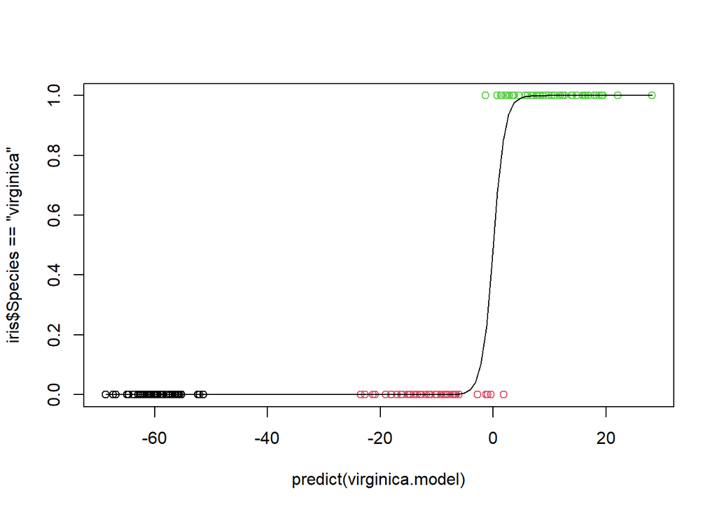

```r
plot(predict(virginica.model), iris$Species=="virginica", col=iris$Species)
rng <- range(predict(virginica.model))
xs <- seq(rng[1],rng[2], length.out=100)
ys <- 1/(1+exp(-xs))
lines(xs,ys)
```

Let’s just contrast this plot with a model that only uses sepal length.

```r
virginica.model.simple <- glm(Species=="virginica" ~ 1 + Sepal.Length, data=iris, family="binomial")
summary(virginica.model.simple)
```

```
##
## Call:
## glm(formula = Species == "virginica" ~ 1 + Sepal.Length, family = "binomial",
##     data = iris)
##
## Deviance Residuals:
##     Min       1Q   Median       3Q      Max
## -1.9870  -0.5520  -0.2614   0.5832   2.7001
##
## Coefficients:
##              Estimate Std. Error z value Pr(>|z|)
## (Intercept)  -16.3198     2.6581  -6.140 8.27e-10 ***
## Sepal.Length   2.5921     0.4316   6.006 1.90e-09 ***
## ---
## Signif. codes:  0 '***' 0.001 '**' 0.01 '*' 0.05 '.' 0.1 ' ' 1
##
## (Dispersion parameter for binomial family taken to be 1)
##
##     Null deviance: 190.95  on 149  degrees of freedom
## Residual deviance: 117.35  on 148  degrees of freedom
## AIC: 121.35
##
## Number of Fisher Scoring iterations: 5
```

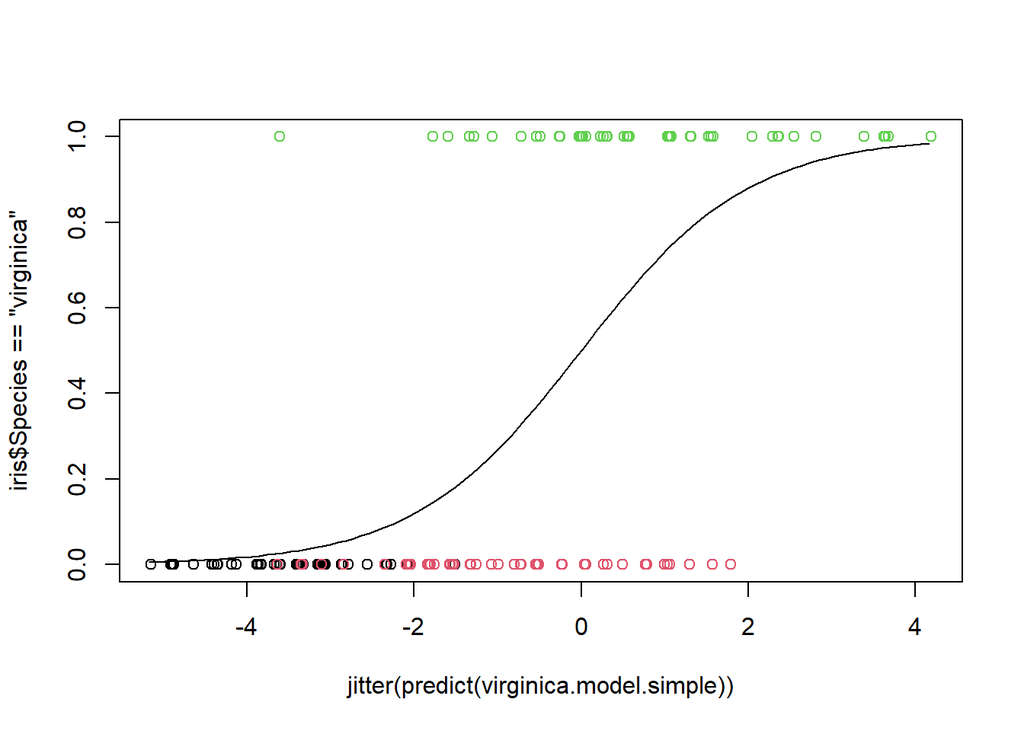

```r
plot(jitter(predict(virginica.model.simple)), iris$Species=="virginica", col=iris$Species)
rng <- range(predict(virginica.model.simple))
xs <- seq(rng[1],rng[2], length.out=100)
ys <- 1/(1+exp(-xs))
lines(xs,ys)
```

How well we did? TRUE represents virginica

```r
table(predict = predict(virginica.model, type="response")>.5, actual = iris$Species=="virginica")
```

```
##        actual
## predict FALSE TRUE
##   FALSE    99    1
##   TRUE      1   49
```

column prop table will show us type 1&2 error rates and power:

```r
prop.table(table(predict = predict(virginica.model, type="response")>.5, actual = iris$Species=="virginica"), margin=2)
```

```
##        actual
## predict FALSE TRUE
##   FALSE  0.99 0.02
##   TRUE   0.01 0.98
```

```r
quantile(predict(virginica.model, type="response")[iris$Species!="virginica"], .95)
```

```
##        95%
## 0.00504067
```

```r
prop.table(table(predict = predict(virginica.model, type="response")>0.00504067 , actual = iris$Species=="virginica"), margin=2)
```

```
##        actual
## predict FALSE TRUE
##   FALSE  0.95 0.00
##   TRUE   0.05 1.00
```

We require very little evidence to claim the flower is virginica, a probability of 0.00504 is enough. In this case we have a 5% type 1 error rate. But note that the power has increased to 100%.

### When a logistic model cannot converge

If your model is so good that it correctly labels everyhing as 1 or zero this is what the output looks like

```r
setosa.model <- glm(Species=="setosa" ~ 1 + Sepal.Length + Sepal.Width+Petal.Length+Petal.Width, data=iris, family="binomial")
summary(setosa.model)
```

```
##
## Call:
## glm(formula = Species == "setosa" ~ 1 + Sepal.Length + Sepal.Width +
##     Petal.Length + Petal.Width, family = "binomial", data = iris)
##
## Deviance Residuals:
##        Min          1Q      Median          3Q         Max
## -3.185e-05  -2.100e-08  -2.100e-08   2.100e-08   3.173e-05
##
## Coefficients:
##                Estimate Std. Error z value Pr(>|z|)
## (Intercept)     -16.946 457457.106       0        1
## Sepal.Length     11.759 130504.043       0        1
## Sepal.Width       7.842  59415.386       0        1
## Petal.Length    -20.088 107724.596       0        1
## Petal.Width     -21.608 154350.619       0        1
##
## (Dispersion parameter for binomial family taken to be 1)
##
##     Null deviance: 1.9095e+02  on 149  degrees of freedom
## Residual deviance: 3.2940e-09  on 145  degrees of freedom
## AIC: 10
##
## Number of Fisher Scoring iterations: 25
```

```r
setosa.model.maxit <- glm(Species=="setosa" ~ 1 + Sepal.Length + Sepal.Width+Petal.Length+Petal.Width, data=iris, family="binomial", control = list(maxit = 2))
summary(setosa.model.maxit)
```

```
##
## Call:
## glm(formula = Species == "setosa" ~ 1 + Sepal.Length + Sepal.Width +
##     Petal.Length + Petal.Width, family = "binomial", data = iris,
##     control = list(maxit = 2))
##
## Deviance Residuals:
##     Min       1Q   Median       3Q      Max
## -0.7003  -0.2994  -0.1592   0.2188   0.7140
##
## Coefficients:
##              Estimate Std. Error z value Pr(>|z|)
## (Intercept)   -2.4428     3.1506  -0.775   0.4381
## Sepal.Length   0.4038     0.8871   0.455   0.6490
## Sepal.Width    1.8157     0.8944   2.030   0.0424 *
## Petal.Length  -1.7249     0.8993  -1.918   0.0551 .
## Petal.Width   -0.2378     1.5787  -0.151   0.8803
## ---
## Signif. codes:  0 '***' 0.001 '**' 0.01 '*' 0.05 '.' 0.1 ' ' 1
##
## (Dispersion parameter for binomial family taken to be 1)
##
##     Null deviance: 190.954  on 149  degrees of freedom
## Residual deviance:  14.313  on 145  degrees of freedom
## AIC: 24.313
##
## Number of Fisher Scoring iterations: 2
```

How correlated are flower measurements?

```r
cor(iris[,1:4])
```

```
##              Sepal.Length Sepal.Width Petal.Length Petal.Width
## Sepal.Length    1.0000000  -0.1175698    0.8717538   0.8179411
## Sepal.Width    -0.1175698   1.0000000   -0.4284401  -0.3661259
## Petal.Length    0.8717538  -0.4284401    1.0000000   0.9628654
## Petal.Width     0.8179411  -0.3661259    0.9628654   1.0000000
```